# Projet Actuariat

## Projets Actuariat-Vie Sujet 5 : Produit de capital décès avec prime annuelle

## importer les packages

```r
library(lifecontingencies)
library(forecast)
library(reliaR)
library(gnm)
library(demography)
library(StMoMo)
```

```r
deaths<-read.table(file = 'deaths.txt',header = TRUE ,fill=TRUE ,sep = "", dec = ".")

head(deaths)
```

```
##   Year Age   Female     Male     Total
## 1 1816   0 76332.26 94997.54 171329.80
## 2 1816   1 17861.24 18659.46  36520.70
## 3 1816   2 11924.14 12466.99  24391.13
## 4 1816   3  7738.20  8083.03  15821.23
## 5 1816   4  5303.44  5507.60  10811.04
## 6 1816   5  4337.85  4452.23   8790.08
```

## Question 2

```r
deaths$Age <- as.numeric(as.character(deaths$Age))
france2010 = deaths[deaths$Year == 2010,]
head(france2010)
```

```
##       Year Age Female Male Total
## 21535 2010   0   1227 1558  2785
## 21536 2010   1    120  103   223
## 21537 2010   2     56   78   134
## 21538 2010   3     42   60   102
## 21539 2010   4     30   37    67
## 21540 2010   5     18   51    69
```

```r
data <- data.frame(france2010)
head(data)
```

```
##       Year Age Female Male Total
## 21535 2010   0   1227 1558  2785
## 21536 2010   1    120  103   223
## 21537 2010   2     56   78   134
## 21538 2010   3     42   60   102
## 21539 2010   4     30   37    67
## 21540 2010   5     18   51    69
```

```r
data$Age[nrow(data)]<-data$Age[nrow(data) - 1] + 1

for (i in 1:nrow(data)) {
  current_age <- data$Age[i]
  data$lx[i] <- nrow(data[data$Age >= current_age,])
}
head(data)
```

```
##       Year Age Female Male Total  lx
## 21535 2010   0   1227 1558  2785 111
## 21536 2010   1    120  103   223 110
## 21537 2010   2     56   78   134 109
## 21538 2010   3     42   60   102 108
## 21539 2010   4     30   37    67 107
## 21540 2010   5     18   51    69 106
```

```r
lifetable <-  new("lifetable", x=data$Age, lx=data$lx ,name="france")
table <- as(lifetable,'data.frame')
head(table)
```

```
##   x  lx        px   ex
## 1 0 111 0.9909910 55.0
## 2 1 110 0.9909091 54.5
## 3 2 109 0.9908257 54.0
## 4 3 108 0.9907407 53.5
## 5 4 107 0.9906542 53.0
## 6 5 106 0.9905660 52.5
```

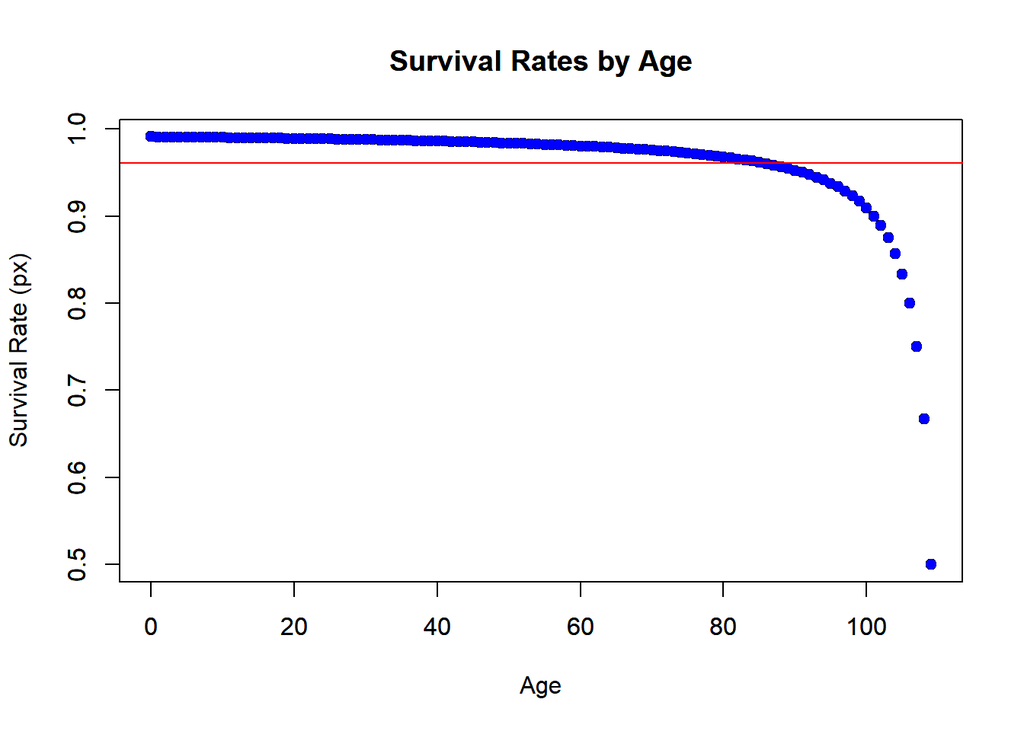

```r
age<- table$x
survivalRate <- table$px

plot(age, survivalRate,
     xlab = "Age",
     ylab = "Survival Rate (px)",
     main = "Survival Rates by Age")


points(age, survivalRate, pch = 16, col = "blue")  # 16 represents circle marker, blue color


abline(h = mean(survivalRate), col = "red", linetype = "dashed")  # Add horizontal line at average mortality
axis(1)  # Show x-axis labels
axis(2)  # Show y-axis labels
title("Survival Rates by Age")
```

## Question 3

1. Préparation des données
2. Spécification du modèle
3. Estimation des paramètres
4. Analyse des résultats Autres modèles disponibles dans le package StMoMo :
- Modèle de Yang-Peterson
- Modèle de Lee-Carter multiplicatif

## Question 4

## Modèle Lee-Carter en choisissant les plages d’âge et de période

- αx : une fonction décroissante pour les âges faibles inférieurs à 25 ans puis une forte croissante jusqu’à la fin de la vie d’ou la plage entre 25 et 100.
- kt : cette fonction décroît sur toute la période, d’ou la plage commence de 1955 jusqu’à 2018.

```r
lafrance <- hmd.mx(country = "FRATNP",username = "khalil.b.khoud1998@gmail.com",password = "Ab&123456",label = "france")


lafrance
```

```
## Mortality data for france
##     Series: female male total
##     Years: 1816 - 2021
##     Ages:  0 - 110
```

```r
carterData <- StMoMoData(data = lafrance, series = "female" ,type = "central")

constLC <- function(ax, bx, kt, b0x, gc, wxt, ages) {
     c1 <- mean(kt[1, ], na.rm = TRUE)
     c2 <- sum(bx[, 1], na.rm = TRUE)
     list(ax = ax + c1 * bx, bx = bx / c2, kt = c2 * (kt - c1))}
age <- 25:100
annees <- 1955:2018
LC <- StMoMo(link = "log", staticAgeFun = TRUE, periodAgeFun = "NP", constFun = constLC)

fitData <- fit(LC, data = carterData, ages.fit = age, years.fit = annees )
```

```
## StMoMo: Start fitting with gnm
## Initialising
## Running start-up iterations..
## Running main iterations.....
## Done
## StMoMo: Finish fitting with gnm
```

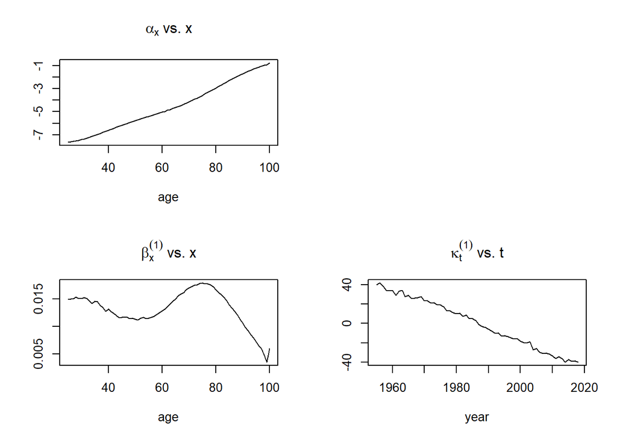

```r
plot(fitData)
```

## Analyse des paramètres :

- αx : la valeur moyenne des logs de la mortalité instantanné ( ln µ( x t, ) au cours du temps ) croit fonction de l’age entre -7 et -1 .
- βx indique la sensibilité de la mortalité instantanée par rapport à l’évolution générale de la mortalité. On constate des pics sur les tranches d’âges entre 20 et 100 ans.
- D’après la figure ci-dessus et comme kt indique l’évolution générale de la mortalité dans le temps ; On constate une tendance linéaire à la décroissance du paramètre k entre 1950 et 2020. Cette tendance à la décroissance du paramètre k devient négatif au cours de la période implique d’après la formule de Lee-Carter une diminution des taux instantanés de mortalité. En conséquence, on assiste à une augmentation de la probabilité de la survie sur la période observée.

## Les résidus du modèle

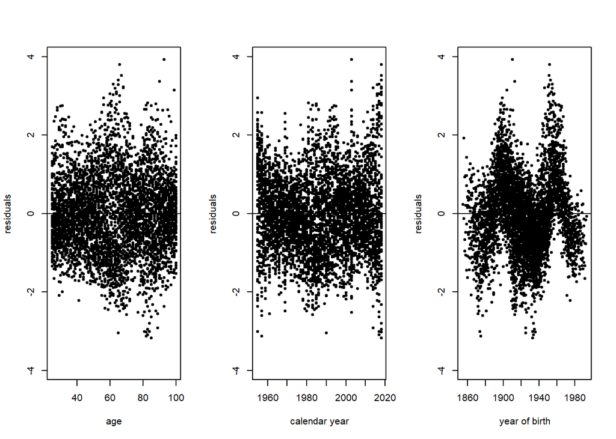

```r
model_res <- resid(fitData)
plot(model_res)
```

## Question 5

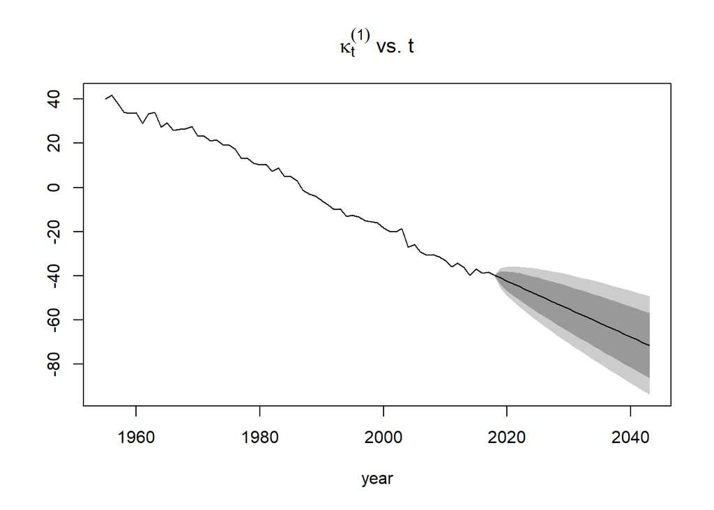

```r
lafrance.smth <- smooth.demogdata(lafrance,method="mspline")
lafranceLcaM <- lca(lafrance.smth ,series ="female" , max.age = 110, adjust="dt")

LcFore=forecast(lafranceLcaM, h = 25 ,method=mean)
lafranceForcast <- forecast(fitData , h = 25, method=mean)
plot(lafranceForcast, only.kt=TRUE)
```

## Question 6

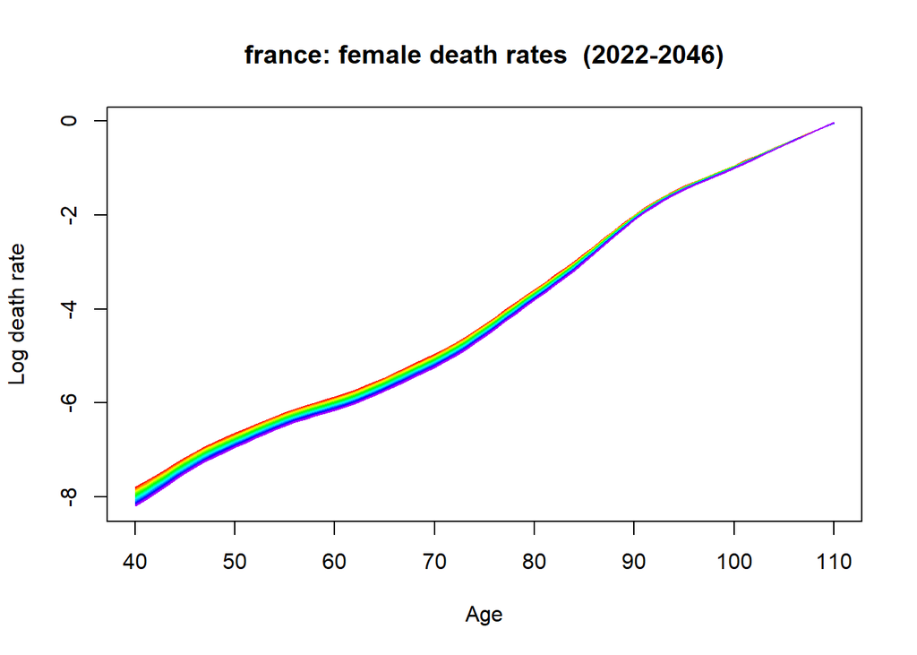

```r
lafrance40 <- extract.ages(LcFore, ages=40:111)
plot(lafrance40)
```

## Question 8

```r
primeAnuelle <- function(ageDeLassure) {
  i <- 0.01
  K <- 20000
  actuarialtable <- new("actuarialtable", x=data$Age, lx=data$lx,interest=i)
  #on calcule les Ax
  ax <- axn(actuarialtable, x=ageDeLassure, m=0)
  Ax <- Axn(actuarialtable, x=ageDeLassure, m=0)
  #selon le principe de Tarification sur le principe d’équité actuarielle
  prime <- K *(Ax / ax)
  prime
}

primeAnuelle(40)
```

```
## [1] 493.2642
```

## Question 8

La VAP dépend de deux facteurs qui sont l’âge de l’assuré et le taux technique i

- Concernant l’âge la VAP crois en fonction de l’âge (corrélation positive ) vu que la probabilité de décès augmente en fonction de ce dernier .
- Le taux technique : La valeur actuelle probable VAP augmente lorsque le taux technique diminue.

## Question 9 (refaire les plots pour les hommes)

```r
carterDataMales <- StMoMoData(data = lafrance, series = "male" ,type = "central")

constLC <- function(ax, bx, kt, b0x, gc, wxt, ages) {
     c1 <- mean(kt[1, ], na.rm = TRUE)
     c2 <- sum(bx[, 1], na.rm = TRUE)
     list(ax = ax + c1 * bx, bx = bx / c2, kt = c2 * (kt - c1))}
age <- 25:100
annees <- 1955:2018
LC <- StMoMo(link = "log", staticAgeFun = TRUE, periodAgeFun = "NP", constFun = constLC)
fitData <- fit(LC, data = carterDataMales, ages.fit = age, years.fit = annees )
```

```
## StMoMo: Start fitting with gnm
## Initialising
## Running start-up iterations..
## Running main iterations........
## Done
## StMoMo: Finish fitting with gnm
```

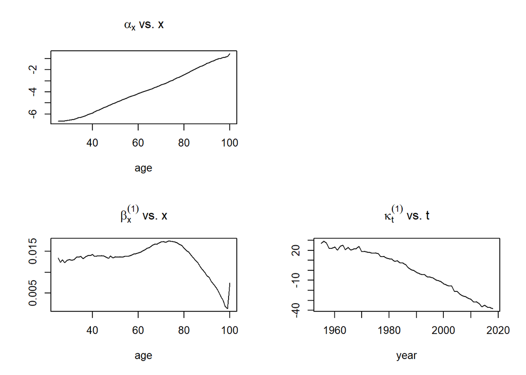

```r
plot(fitData)
```

## Le résidus du modèle

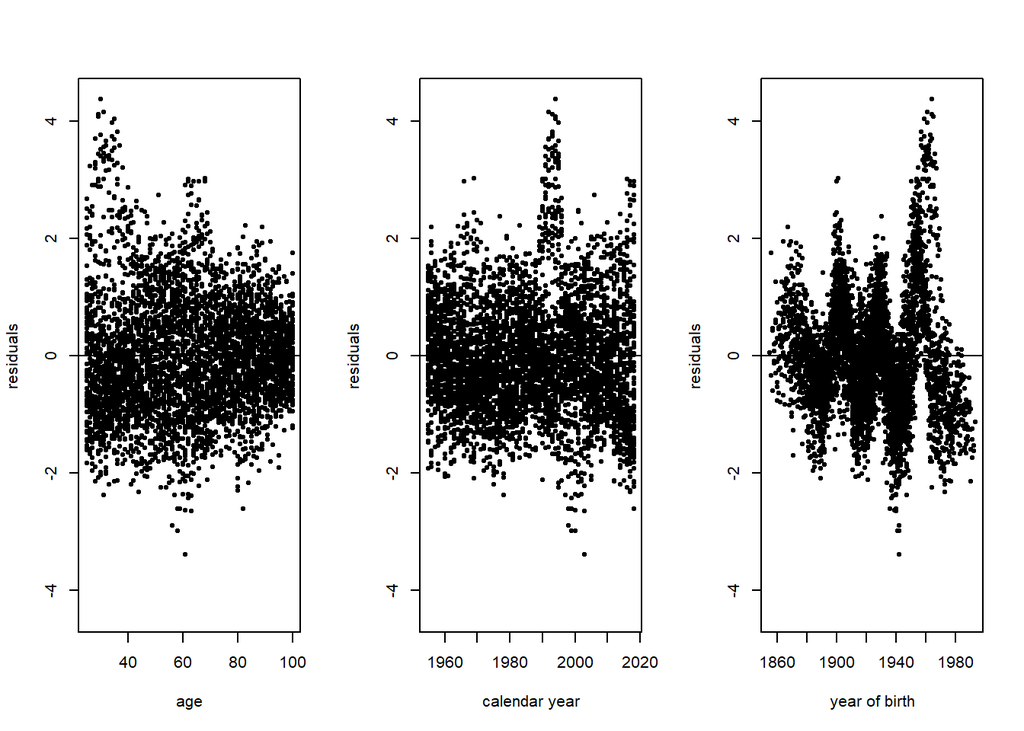

```r
model_res <- resid(fitData)
plot(model_res)
```

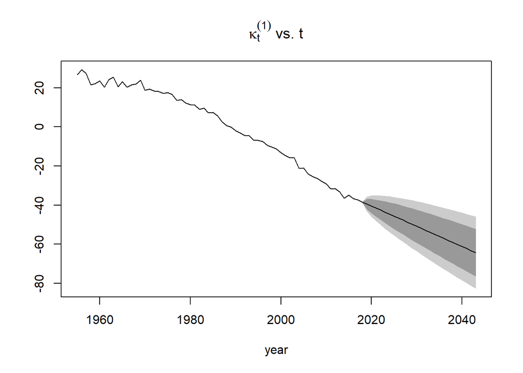

```r
lafrance.smth <- smooth.demogdata(lafrance,method="mspline")
lafranceLcaM <- lca(lafrance.smth ,series ="male" , max.age = 110, adjust="dt")

LcFore=forecast(lafranceLcaM, h = 25 ,method=mean)
lafranceForcast <- forecast(fitData , h = 25, method=mean)
plot(lafranceForcast, only.kt=TRUE)
```

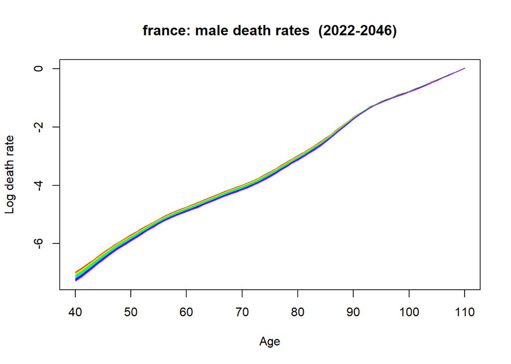

```r
lafrance40 <- extract.ages(LcFore, ages=40:111)
plot(lafrance40)
```

## on constate les changements suivants

- les paramètres d’un modèle de Lee-Carter changents légérement ainsi que leurs pentes
- la pente du forecast change légérement
- la courbe des taux de mortalité est moins épaisse chez les hommes